# Risk Factor Analysis

## Outcome Variable

**Outcome Variable:** haz

## Predictor Variables

**Intervention Variable:** hfoodsec

**Adjustment Set:**

unadjusted

## Stratifying Variables

The analysis was stratified on these variable(s):

- agecat
- studyid
- country

## Data Summary

| agecat | studyid | country | hfoodsec | n_cell | n |
| --- | --- | --- | --- | --- | --- |
| Birth | ki0047075b-MAL-ED | BANGLADESH | Food Secure | 157 | 188 |
| Birth | ki0047075b-MAL-ED | BANGLADESH | Mildly Food Insecure | 4 | 188 |
| Birth | ki0047075b-MAL-ED | BANGLADESH | Food Insecure | 27 | 188 |
| Birth | ki0047075b-MAL-ED | BRAZIL | Food Secure | 0 | 105 |
| Birth | ki0047075b-MAL-ED | BRAZIL | Mildly Food Insecure | 11 | 105 |
| Birth | ki0047075b-MAL-ED | BRAZIL | Food Insecure | 94 | 105 |
| Birth | ki0047075b-MAL-ED | INDIA | Food Secure | 154 | 170 |
| Birth | ki0047075b-MAL-ED | INDIA | Mildly Food Insecure | 2 | 170 |
| Birth | ki0047075b-MAL-ED | INDIA | Food Insecure | 14 | 170 |
| Birth | ki0047075b-MAL-ED | NEPAL | Food Secure | 76 | 98 |
| Birth | ki0047075b-MAL-ED | NEPAL | Mildly Food Insecure | 9 | 98 |
| Birth | ki0047075b-MAL-ED | NEPAL | Food Insecure | 13 | 98 |
| Birth | ki0047075b-MAL-ED | PERU | Food Secure | 27 | 107 |
| Birth | ki0047075b-MAL-ED | PERU | Mildly Food Insecure | 25 | 107 |
| Birth | ki0047075b-MAL-ED | PERU | Food Insecure | 55 | 107 |
| Birth | ki0047075b-MAL-ED | SOUTH AFRICA | Food Secure | 107 | 195 |
| Birth | ki0047075b-MAL-ED | SOUTH AFRICA | Mildly Food Insecure | 17 | 195 |
| Birth | ki0047075b-MAL-ED | SOUTH AFRICA | Food Insecure | 71 | 195 |
| Birth | ki1017093-NIH-Birth | BANGLADESH | Food Secure | 3 | 28 |
| Birth | ki1017093-NIH-Birth | BANGLADESH | Mildly Food Insecure | 21 | 28 |
| Birth | ki1017093-NIH-Birth | BANGLADESH | Food Insecure | 4 | 28 |
| Birth | ki1017093c-NIH-Crypto | BANGLADESH | Food Secure | 14 | 27 |
| Birth | ki1017093c-NIH-Crypto | BANGLADESH | Mildly Food Insecure | 9 | 27 |
| Birth | ki1017093c-NIH-Crypto | BANGLADESH | Food Insecure | 4 | 27 |
| Birth | kiGH5241-JiVitA-3 | BANGLADESH | Food Secure | 5997 | 12605 |
| Birth | kiGH5241-JiVitA-3 | BANGLADESH | Mildly Food Insecure | 4335 | 12605 |
| Birth | kiGH5241-JiVitA-3 | BANGLADESH | Food Insecure | 2273 | 12605 |
| Birth | kiGH5241-JiVitA-4 | BANGLADESH | Food Secure | 396 | 819 |
| Birth | kiGH5241-JiVitA-4 | BANGLADESH | Mildly Food Insecure | 309 | 819 |
| Birth | kiGH5241-JiVitA-4 | BANGLADESH | Food Insecure | 114 | 819 |

[output cut: 66 more lines]

The following strata were considered:

- agecat: 24 months, studyid: ki0047075b-MAL-ED, country: BANGLADESH
- agecat: 24 months, studyid: ki0047075b-MAL-ED, country: BRAZIL
- agecat: 24 months, studyid: ki0047075b-MAL-ED, country: INDIA
- agecat: 24 months, studyid: ki0047075b-MAL-ED, country: NEPAL
- agecat: 24 months, studyid: ki0047075b-MAL-ED, country: PERU
- agecat: 24 months, studyid: ki0047075b-MAL-ED, country: SOUTH AFRICA
- agecat: 24 months, studyid: ki1017093-NIH-Birth, country: BANGLADESH
- agecat: 24 months, studyid: ki1017093c-NIH-Crypto, country: BANGLADESH
- agecat: 24 months, studyid: ki1113344-GMS-Nepal, country: NEPAL
- agecat: 24 months, studyid: kiGH5241-JiVitA-3, country: BANGLADESH
- agecat: 24 months, studyid: kiGH5241-JiVitA-4, country: BANGLADESH
- agecat: 6 months, studyid: ki0047075b-MAL-ED, country: BANGLADESH
- agecat: 6 months, studyid: ki0047075b-MAL-ED, country: BRAZIL
- agecat: 6 months, studyid: ki0047075b-MAL-ED, country: INDIA
- agecat: 6 months, studyid: ki0047075b-MAL-ED, country: NEPAL
- agecat: 6 months, studyid: ki0047075b-MAL-ED, country: PERU
- agecat: 6 months, studyid: ki0047075b-MAL-ED, country: SOUTH AFRICA
- agecat: 6 months, studyid: ki1017093-NIH-Birth, country: BANGLADESH
- agecat: 6 months, studyid: ki1017093c-NIH-Crypto, country: BANGLADESH
- agecat: 6 months, studyid: ki1113344-GMS-Nepal, country: NEPAL
- agecat: 6 months, studyid: kiGH5241-JiVitA-3, country: BANGLADESH
- agecat: 6 months, studyid: kiGH5241-JiVitA-4, country: BANGLADESH
- agecat: Birth, studyid: ki0047075b-MAL-ED, country: BANGLADESH
- agecat: Birth, studyid: ki0047075b-MAL-ED, country: BRAZIL
- agecat: Birth, studyid: ki0047075b-MAL-ED, country: INDIA
- agecat: Birth, studyid: ki0047075b-MAL-ED, country: NEPAL
- agecat: Birth, studyid: ki0047075b-MAL-ED, country: PERU
- agecat: Birth, studyid: ki0047075b-MAL-ED, country: SOUTH AFRICA
- agecat: Birth, studyid: ki1017093-NIH-Birth, country: BANGLADESH
- agecat: Birth, studyid: ki1017093c-NIH-Crypto, country: BANGLADESH
- agecat: Birth, studyid: kiGH5241-JiVitA-3, country: BANGLADESH
- agecat: Birth, studyid: kiGH5241-JiVitA-4, country: BANGLADESH

### Dropped Strata

Some strata were dropped due to rare outcomes:

- agecat: Birth, studyid: ki0047075b-MAL-ED, country: BANGLADESH
- agecat: Birth, studyid: ki0047075b-MAL-ED, country: BRAZIL
- agecat: Birth, studyid: ki0047075b-MAL-ED, country: INDIA
- agecat: Birth, studyid: ki1017093-NIH-Birth, country: BANGLADESH
- agecat: Birth, studyid: ki1017093c-NIH-Crypto, country: BANGLADESH
- agecat: 6 months, studyid: ki0047075b-MAL-ED, country: BANGLADESH
- agecat: 6 months, studyid: ki0047075b-MAL-ED, country: BRAZIL
- agecat: 24 months, studyid: ki0047075b-MAL-ED, country: BANGLADESH
- agecat: 24 months, studyid: ki0047075b-MAL-ED, country: BRAZIL

## Methods Detail

We’re interested in the causal parameters $E[Y_a]$ for all values of $a \in \mathcal{A}$. These parameters represent the mean outcome if, possibly contrary to fact, we intervened to set all units to have $A=a$. Under the randomization and positivity assumptions, these are identified by the statistical parameters $\psi_a=E_W[E_{Y|A,W}(Y|A=a,W)]$. In addition, we’re interested in the mean of $Y$, $E[Y]$ under no intervention (the observed mean). We will estimate these parameters by using SuperLearner to fit the relevant likelihood factors – $E_{Y|A,W}(Y|A=a,W)$ and $p(A=a|W)$, and then updating our likelihood fit using a joint TMLE.

For unadjusted analyses ($W=\{\}$), initial likelihoods were estimated using Lrnr_glm to estimate the simple $E(Y|A)$ and Lrnr_mean to estimate $p(A)$. For adjusted analyses, a small library containing Lrnr_glmnet, Lrnr_xgboost, and Lrnr_mean was used.

Having estimated these parameters, we will then use the delta method to estimate relative risks and attributable risks relative to a prespecified baseline level of $A$.

# Results Detail

## Results Plots

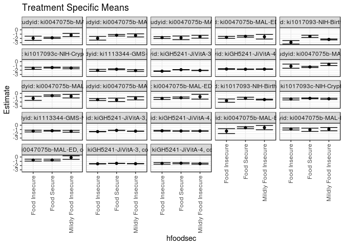

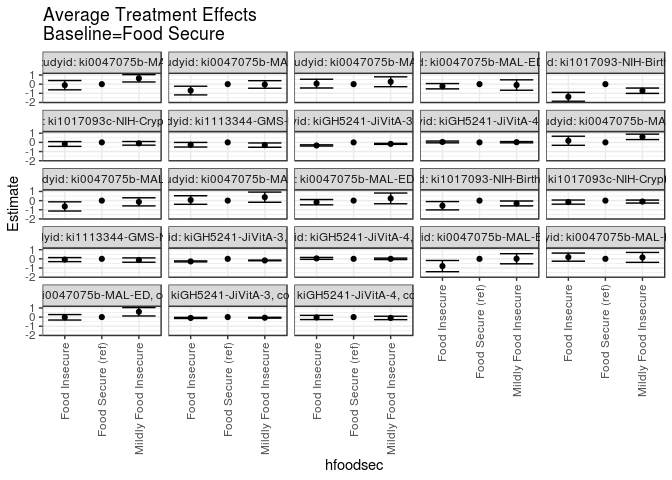

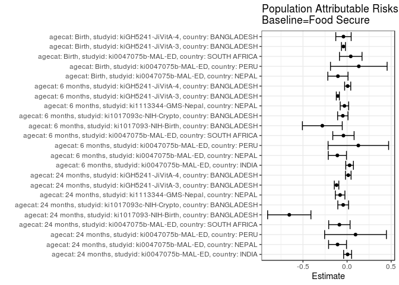

## Results Table

### Parameter: TSM

| agecat | studyid | country | intervention_level | baseline_level | estimate | ci_lower | ci_upper |
| --- | --- | --- | --- | --- | --- | --- | --- |
| Birth | ki0047075b-MAL-ED | NEPAL | Food Secure | NA | -0.5764474 | -0.7891541 | -0.3637406 |
| Birth | ki0047075b-MAL-ED | NEPAL | Mildly Food Insecure | NA | -0.5644444 | -1.0737762 | -0.0551126 |
| Birth | ki0047075b-MAL-ED | NEPAL | Food Insecure | NA | -1.3684615 | -1.9425417 | -0.7943814 |
| Birth | ki0047075b-MAL-ED | PERU | Food Secure | NA | -1.0718519 | -1.4522274 | -0.6914763 |
| Birth | ki0047075b-MAL-ED | PERU | Mildly Food Insecure | NA | -0.9152000 | -1.3029555 | -0.5274445 |
| Birth | ki0047075b-MAL-ED | PERU | Food Insecure | NA | -0.8841818 | -1.1124025 | -0.6559612 |
| Birth | ki0047075b-MAL-ED | SOUTH AFRICA | Food Secure | NA | -0.7064486 | -0.9005011 | -0.5123961 |
| Birth | ki0047075b-MAL-ED | SOUTH AFRICA | Mildly Food Insecure | NA | -0.1258824 | -0.5421722 | 0.2904075 |
| Birth | ki0047075b-MAL-ED | SOUTH AFRICA | Food Insecure | NA | -0.7309859 | -0.9574441 | -0.5045277 |
| Birth | kiGH5241-JiVitA-3 | BANGLADESH | Food Secure | NA | -1.4869568 | -1.5185110 | -1.4554027 |
| Birth | kiGH5241-JiVitA-3 | BANGLADESH | Mildly Food Insecure | NA | -1.5573933 | -1.5949365 | -1.5198501 |
| Birth | kiGH5241-JiVitA-3 | BANGLADESH | Food Insecure | NA | -1.5804795 | -1.6313521 | -1.5296070 |
| Birth | kiGH5241-JiVitA-4 | BANGLADESH | Food Secure | NA | -1.4592172 | -1.5910598 | -1.3273745 |
| Birth | kiGH5241-JiVitA-4 | BANGLADESH | Mildly Food Insecure | NA | -1.5527184 | -1.6838270 | -1.4216099 |
| Birth | kiGH5241-JiVitA-4 | BANGLADESH | Food Insecure | NA | -1.4992982 | -1.6859558 | -1.3126407 |
| 6 months | ki0047075b-MAL-ED | INDIA | Food Secure | NA | -1.2392193 | -1.3694179 | -1.1090207 |
| 6 months | ki0047075b-MAL-ED | INDIA | Mildly Food Insecure | NA | -0.6360000 | -0.9019405 | -0.3700595 |
| 6 months | ki0047075b-MAL-ED | INDIA | Food Insecure | NA | -1.0620588 | -1.5420342 | -0.5820835 |
| 6 months | ki0047075b-MAL-ED | NEPAL | Food Secure | NA | -0.5152660 | -0.6738897 | -0.3566422 |
| 6 months | ki0047075b-MAL-ED | NEPAL | Mildly Food Insecure | NA | -0.6500000 | -1.0624500 | -0.2375500 |
| 6 months | ki0047075b-MAL-ED | NEPAL | Food Insecure | NA | -1.1502632 | -1.6292612 | -0.6712652 |
| 6 months | ki0047075b-MAL-ED | PERU | Food Secure | NA | -1.5070370 | -1.9126067 | -1.1014673 |
| 6 months | ki0047075b-MAL-ED | PERU | Mildly Food Insecure | NA | -1.1319643 | -1.5097115 | -0.7542171 |
| 6 months | ki0047075b-MAL-ED | PERU | Food Insecure | NA | -1.4411905 | -1.6732546 | -1.2091264 |
| 6 months | ki0047075b-MAL-ED | SOUTH AFRICA | Food Secure | NA | -1.0127907 | -1.1878124 | -0.8377690 |
| 6 months | ki0047075b-MAL-ED | SOUTH AFRICA | Mildly Food Insecure | NA | -0.7707407 | -1.3286896 | -0.2127919 |
| 6 months | ki0047075b-MAL-ED | SOUTH AFRICA | Food Insecure | NA | -1.1825206 | -1.4123288 | -0.9527123 |
| 6 months | ki1017093-NIH-Birth | BANGLADESH | Food Secure | NA | -1.1268542 | -1.3747544 | -0.8789539 |
| 6 months | ki1017093-NIH-Birth | BANGLADESH | Mildly Food Insecure | NA | -1.4343905 | -1.5303921 | -1.3383889 |
| 6 months | ki1017093-NIH-Birth | BANGLADESH | Food Insecure | NA | -1.6868750 | -2.0695528 | -1.3041972 |
| 6 months | ki1017093c-NIH-Crypto | BANGLADESH | Food Secure | NA | -1.1502927 | -1.2422659 | -1.0583196 |
| 6 months | ki1017093c-NIH-Crypto | BANGLADESH | Mildly Food Insecure | NA | -1.2534804 | -1.3885153 | -1.1184455 |
| 6 months | ki1017093c-NIH-Crypto | BANGLADESH | Food Insecure | NA | -1.3115476 | -1.5163063 | -1.1067890 |
| 6 months | ki1113344-GMS-Nepal | NEPAL | Food Secure | NA | -1.2937511 | -1.3854100 | -1.2020921 |
| 6 months | ki1113344-GMS-Nepal | NEPAL | Mildly Food Insecure | NA | -1.4271711 | -1.6431345 | -1.2112076 |
| 6 months | ki1113344-GMS-Nepal | NEPAL | Food Insecure | NA | -1.3767568 | -1.5761078 | -1.1774057 |
| 6 months | kiGH5241-JiVitA-3 | BANGLADESH | Food Secure | NA | -1.2085241 | -1.2373871 | -1.1796610 |
| 6 months | kiGH5241-JiVitA-3 | BANGLADESH | Mildly Food Insecure | NA | -1.3834470 | -1.4145136 | -1.3523804 |
| 6 months | kiGH5241-JiVitA-3 | BANGLADESH | Food Insecure | NA | -1.4884679 | -1.5371084 | -1.4398274 |
| 6 months | kiGH5241-JiVitA-4 | BANGLADESH | Food Secure | NA | -1.3516687 | -1.4036005 | -1.2997369 |
| 6 months | kiGH5241-JiVitA-4 | BANGLADESH | Mildly Food Insecure | NA | -1.3494563 | -1.4092035 | -1.2897092 |
| 6 months | kiGH5241-JiVitA-4 | BANGLADESH | Food Insecure | NA | -1.3040354 | -1.3938912 | -1.2141795 |
| 24 months | ki0047075b-MAL-ED | INDIA | Food Secure | NA | -1.8536842 | -1.9918894 | -1.7154790 |
| 24 months | ki0047075b-MAL-ED | INDIA | Mildly Food Insecure | NA | -1.2150000 | -1.5912720 | -0.8387280 |
| 24 months | ki0047075b-MAL-ED | INDIA | Food Insecure | NA | -1.9661765 | -2.4561419 | -1.4762110 |
| 24 months | ki0047075b-MAL-ED | NEPAL | Food Secure | NA | -1.2695745 | -1.4551661 | -1.0839828 |
| 24 months | ki0047075b-MAL-ED | NEPAL | Mildly Food Insecure | NA | -1.3040000 | -1.6710505 | -0.9369495 |
| 24 months | ki0047075b-MAL-ED | NEPAL | Food Insecure | NA | -1.9702632 | -2.4051384 | -1.5353879 |
| 24 months | ki0047075b-MAL-ED | PERU | Food Secure | NA | -1.8719231 | -2.2957189 | -1.4481273 |
| 24 months | ki0047075b-MAL-ED | PERU | Mildly Food Insecure | NA | -1.6107407 | -1.9426264 | -1.2788550 |
| 24 months | ki0047075b-MAL-ED | PERU | Food Insecure | NA | -1.8125926 | -2.0335673 | -1.5916179 |
| 24 months | ki0047075b-MAL-ED | SOUTH AFRICA | Food Secure | NA | -1.5236822 | -1.7051934 | -1.3421710 |
| 24 months | ki0047075b-MAL-ED | SOUTH AFRICA | Mildly Food Insecure | NA | -1.6183333 | -2.1576472 | -1.0790195 |
| 24 months | ki0047075b-MAL-ED | SOUTH AFRICA | Food Insecure | NA | -1.7479630 | -1.9747248 | -1.5212012 |
| 24 months | ki1017093-NIH-Birth | BANGLADESH | Food Secure | NA | -1.5254412 | -1.7953122 | -1.2555702 |
| 24 months | ki1017093-NIH-Birth | BANGLADESH | Mildly Food Insecure | NA | -2.2435976 | -2.3514068 | -2.1357884 |
| 24 months | ki1017093-NIH-Birth | BANGLADESH | Food Insecure | NA | -2.9069949 | -3.3056999 | -2.5082900 |
| 24 months | ki1017093c-NIH-Crypto | BANGLADESH | Food Secure | NA | -1.3854192 | -1.4890285 | -1.2818098 |
| 24 months | ki1017093c-NIH-Crypto | BANGLADESH | Mildly Food Insecure | NA | -1.4891935 | -1.6593517 | -1.3190354 |
| 24 months | ki1017093c-NIH-Crypto | BANGLADESH | Food Insecure | NA | -1.5605357 | -1.8000689 | -1.3210025 |
| 24 months | ki1113344-GMS-Nepal | NEPAL | Food Secure | NA | -1.7870965 | -1.8865868 | -1.6876061 |
| 24 months | ki1113344-GMS-Nepal | NEPAL | Mildly Food Insecure | NA | -2.0848551 | -2.2974013 | -1.8723089 |
| 24 months | ki1113344-GMS-Nepal | NEPAL | Food Insecure | NA | -2.0436429 | -2.2759121 | -1.8113736 |
| 24 months | kiGH5241-JiVitA-3 | BANGLADESH | Food Secure | NA | -1.8898194 | -1.9280989 | -1.8515398 |
| 24 months | kiGH5241-JiVitA-3 | BANGLADESH | Mildly Food Insecure | NA | -2.0525570 | -2.0950697 | -2.0100443 |
| 24 months | kiGH5241-JiVitA-3 | BANGLADESH | Food Insecure | NA | -2.2251521 | -2.2822053 | -2.1680989 |
| 24 months | kiGH5241-JiVitA-4 | BANGLADESH | Food Secure | NA | -1.7712047 | -1.8203852 | -1.7220241 |
| 24 months | kiGH5241-JiVitA-4 | BANGLADESH | Mildly Food Insecure | NA | -1.7505806 | -1.8057415 | -1.6954198 |
| 24 months | kiGH5241-JiVitA-4 | BANGLADESH | Food Insecure | NA | -1.7243678 | -1.8112862 | -1.6374494 |

### Parameter: E(Y)

| agecat | studyid | country | intervention_level | baseline_level | estimate | ci_lower | ci_upper |
| --- | --- | --- | --- | --- | --- | --- | --- |
| Birth | ki0047075b-MAL-ED | NEPAL | NA | NA | -0.6804082 | -0.8755126 | -0.4853037 |
| Birth | ki0047075b-MAL-ED | PERU | NA | NA | -0.9387850 | -1.1159974 | -0.7615727 |
| Birth | ki0047075b-MAL-ED | SOUTH AFRICA | NA | NA | -0.6647692 | -0.8062103 | -0.5233282 |
| Birth | kiGH5241-JiVitA-3 | BANGLADESH | NA | NA | -1.5280452 | -1.5507110 | -1.5053794 |
| Birth | kiGH5241-JiVitA-4 | BANGLADESH | NA | NA | -1.5000733 | -1.5844715 | -1.4156751 |
| 6 months | ki0047075b-MAL-ED | INDIA | NA | NA | -1.2107862 | -1.3345960 | -1.0869764 |
| 6 months | ki0047075b-MAL-ED | NEPAL | NA | NA | -0.6253125 | -0.7752118 | -0.4754132 |
| 6 months | ki0047075b-MAL-ED | PERU | NA | NA | -1.3792042 | -1.5615886 | -1.1968198 |
| 6 months | ki0047075b-MAL-ED | SOUTH AFRICA | NA | NA | -1.0539803 | -1.1904887 | -0.9174718 |
| 6 months | ki1017093-NIH-Birth | BANGLADESH | NA | NA | -1.4073821 | -1.4960598 | -1.3187043 |
| 6 months | ki1017093c-NIH-Crypto | BANGLADESH | NA | NA | -1.1986783 | -1.2700937 | -1.1272630 |
| 6 months | ki1113344-GMS-Nepal | NEPAL | NA | NA | -1.3236269 | -1.4015413 | -1.2457125 |
| 6 months | kiGH5241-JiVitA-3 | BANGLADESH | NA | NA | -1.3131326 | -1.3362851 | -1.2899801 |
| 6 months | kiGH5241-JiVitA-4 | BANGLADESH | NA | NA | -1.3446891 | -1.3822219 | -1.3071564 |
| 24 months | ki0047075b-MAL-ED | INDIA | NA | NA | -1.8476415 | -1.9786652 | -1.7166178 |
| 24 months | ki0047075b-MAL-ED | NEPAL | NA | NA | -1.3776172 | -1.5402475 | -1.2149868 |
| 24 months | ki0047075b-MAL-ED | PERU | NA | NA | -1.7760748 | -1.9504595 | -1.6016900 |
| 24 months | ki0047075b-MAL-ED | SOUTH AFRICA | NA | NA | -1.6108333 | -1.7488019 | -1.4728648 |
| 24 months | ki1017093-NIH-Birth | BANGLADESH | NA | NA | -2.1807945 | -2.2835902 | -2.0779987 |
| 24 months | ki1017093c-NIH-Crypto | BANGLADESH | NA | NA | -1.4295331 | -1.5127726 | -1.3462935 |
| 24 months | ki1113344-GMS-Nepal | NEPAL | NA | NA | -1.8659973 | -1.9508504 | -1.7811442 |
| 24 months | kiGH5241-JiVitA-3 | BANGLADESH | NA | NA | -2.0089421 | -2.0368231 | -1.9810610 |
| 24 months | kiGH5241-JiVitA-4 | BANGLADESH | NA | NA | -1.7576915 | -1.7933270 | -1.7220560 |

### Parameter: ATE

| agecat | studyid | country | intervention_level | baseline_level | estimate | ci_lower | ci_upper |
| --- | --- | --- | --- | --- | --- | --- | --- |
| Birth | ki0047075b-MAL-ED | NEPAL | Food Secure | Food Secure | 0.0000000 | 0.0000000 | 0.0000000 |
| Birth | ki0047075b-MAL-ED | NEPAL | Mildly Food Insecure | Food Secure | 0.0120029 | -0.5399600 | 0.5639658 |
| Birth | ki0047075b-MAL-ED | NEPAL | Food Insecure | Food Secure | -0.7920142 | -1.4042332 | -0.1797951 |
| Birth | ki0047075b-MAL-ED | PERU | Food Secure | Food Secure | 0.0000000 | 0.0000000 | 0.0000000 |
| Birth | ki0047075b-MAL-ED | PERU | Mildly Food Insecure | Food Secure | 0.1566519 | -0.3865239 | 0.6998276 |
| Birth | ki0047075b-MAL-ED | PERU | Food Insecure | Food Secure | 0.1876700 | -0.2559179 | 0.6312579 |
| Birth | ki0047075b-MAL-ED | SOUTH AFRICA | Food Secure | Food Secure | 0.0000000 | 0.0000000 | 0.0000000 |
| Birth | ki0047075b-MAL-ED | SOUTH AFRICA | Mildly Food Insecure | Food Secure | 0.5805662 | 0.1212694 | 1.0398631 |
| Birth | ki0047075b-MAL-ED | SOUTH AFRICA | Food Insecure | Food Secure | -0.0245373 | -0.3227649 | 0.2736902 |
| Birth | kiGH5241-JiVitA-3 | BANGLADESH | Food Secure | Food Secure | 0.0000000 | 0.0000000 | 0.0000000 |
| Birth | kiGH5241-JiVitA-3 | BANGLADESH | Mildly Food Insecure | Food Secure | -0.0704365 | -0.1181225 | -0.0227505 |
| Birth | kiGH5241-JiVitA-3 | BANGLADESH | Food Insecure | Food Secure | -0.0935227 | -0.1530196 | -0.0340259 |
| Birth | kiGH5241-JiVitA-4 | BANGLADESH | Food Secure | Food Secure | 0.0000000 | 0.0000000 | 0.0000000 |
| Birth | kiGH5241-JiVitA-4 | BANGLADESH | Mildly Food Insecure | Food Secure | -0.0935013 | -0.2783726 | 0.0913701 |
| Birth | kiGH5241-JiVitA-4 | BANGLADESH | Food Insecure | Food Secure | -0.0400811 | -0.2694269 | 0.1892647 |
| 6 months | ki0047075b-MAL-ED | INDIA | Food Secure | Food Secure | 0.0000000 | 0.0000000 | 0.0000000 |
| 6 months | ki0047075b-MAL-ED | INDIA | Mildly Food Insecure | Food Secure | 0.6032193 | 0.3071180 | 0.8993206 |
| 6 months | ki0047075b-MAL-ED | INDIA | Food Insecure | Food Secure | 0.1771605 | -0.3201603 | 0.6744813 |
| 6 months | ki0047075b-MAL-ED | NEPAL | Food Secure | Food Secure | 0.0000000 | 0.0000000 | 0.0000000 |
| 6 months | ki0047075b-MAL-ED | NEPAL | Mildly Food Insecure | Food Secure | -0.1347340 | -0.5766351 | 0.3071670 |
| 6 months | ki0047075b-MAL-ED | NEPAL | Food Insecure | Food Secure | -0.6349972 | -1.1395768 | -0.1304176 |
| 6 months | ki0047075b-MAL-ED | PERU | Food Secure | Food Secure | 0.0000000 | 0.0000000 | 0.0000000 |
| 6 months | ki0047075b-MAL-ED | PERU | Mildly Food Insecure | Food Secure | 0.3750728 | -0.1791652 | 0.9293107 |
| 6 months | ki0047075b-MAL-ED | PERU | Food Insecure | Food Secure | 0.0658466 | -0.4014227 | 0.5331158 |
| 6 months | ki0047075b-MAL-ED | SOUTH AFRICA | Food Secure | Food Secure | 0.0000000 | 0.0000000 | 0.0000000 |
| 6 months | ki0047075b-MAL-ED | SOUTH AFRICA | Mildly Food Insecure | Food Secure | 0.2420500 | -0.3427060 | 0.8268059 |
| 6 months | ki0047075b-MAL-ED | SOUTH AFRICA | Food Insecure | Food Secure | -0.1697299 | -0.4585974 | 0.1191376 |
| 6 months | ki1017093-NIH-Birth | BANGLADESH | Food Secure | Food Secure | 0.0000000 | 0.0000000 | 0.0000000 |
| 6 months | ki1017093-NIH-Birth | BANGLADESH | Mildly Food Insecure | Food Secure | -0.3075363 | -0.5733762 | -0.0416964 |
| 6 months | ki1017093-NIH-Birth | BANGLADESH | Food Insecure | Food Secure | -0.5600208 | -1.0159779 | -0.1040638 |
| 6 months | ki1017093c-NIH-Crypto | BANGLADESH | Food Secure | Food Secure | 0.0000000 | 0.0000000 | 0.0000000 |
| 6 months | ki1017093c-NIH-Crypto | BANGLADESH | Mildly Food Insecure | Food Secure | -0.1031877 | -0.2665691 | 0.0601938 |
| 6 months | ki1017093c-NIH-Crypto | BANGLADESH | Food Insecure | Food Secure | -0.1612549 | -0.3857213 | 0.0632115 |
| 6 months | ki1113344-GMS-Nepal | NEPAL | Food Secure | Food Secure | 0.0000000 | 0.0000000 | 0.0000000 |
| 6 months | ki1113344-GMS-Nepal | NEPAL | Mildly Food Insecure | Food Secure | -0.1334200 | -0.3680294 | 0.1011894 |
| 6 months | ki1113344-GMS-Nepal | NEPAL | Food Insecure | Food Secure | -0.0830057 | -0.3024190 | 0.1364076 |
| 6 months | kiGH5241-JiVitA-3 | BANGLADESH | Food Secure | Food Secure | 0.0000000 | 0.0000000 | 0.0000000 |
| 6 months | kiGH5241-JiVitA-3 | BANGLADESH | Mildly Food Insecure | Food Secure | -0.1749229 | -0.2112507 | -0.1385951 |
| 6 months | kiGH5241-JiVitA-3 | BANGLADESH | Food Insecure | Food Secure | -0.2799439 | -0.3335067 | -0.2263810 |
| 6 months | kiGH5241-JiVitA-4 | BANGLADESH | Food Secure | Food Secure | 0.0000000 | 0.0000000 | 0.0000000 |
| 6 months | kiGH5241-JiVitA-4 | BANGLADESH | Mildly Food Insecure | Food Secure | 0.0022124 | -0.0742412 | 0.0786660 |
| 6 months | kiGH5241-JiVitA-4 | BANGLADESH | Food Insecure | Food Secure | 0.0476333 | -0.0558224 | 0.1510891 |
| 24 months | ki0047075b-MAL-ED | INDIA | Food Secure | Food Secure | 0.0000000 | 0.0000000 | 0.0000000 |
| 24 months | ki0047075b-MAL-ED | INDIA | Mildly Food Insecure | Food Secure | 0.6386842 | 0.2378335 | 1.0395349 |
| 24 months | ki0047075b-MAL-ED | INDIA | Food Insecure | Food Secure | -0.1124923 | -0.6215766 | 0.3965921 |
| 24 months | ki0047075b-MAL-ED | NEPAL | Food Secure | Food Secure | 0.0000000 | 0.0000000 | 0.0000000 |
| 24 months | ki0047075b-MAL-ED | NEPAL | Mildly Food Insecure | Food Secure | -0.0344255 | -0.4457288 | 0.3768777 |
| 24 months | ki0047075b-MAL-ED | NEPAL | Food Insecure | Food Secure | -0.7006887 | -1.1735108 | -0.2278666 |
| 24 months | ki0047075b-MAL-ED | PERU | Food Secure | Food Secure | 0.0000000 | 0.0000000 | 0.0000000 |
| 24 months | ki0047075b-MAL-ED | PERU | Mildly Food Insecure | Food Secure | 0.2611823 | -0.2771029 | 0.7994676 |
| 24 months | ki0047075b-MAL-ED | PERU | Food Insecure | Food Secure | 0.0593305 | -0.4186158 | 0.5372768 |
| 24 months | ki0047075b-MAL-ED | SOUTH AFRICA | Food Secure | Food Secure | 0.0000000 | 0.0000000 | 0.0000000 |
| 24 months | ki0047075b-MAL-ED | SOUTH AFRICA | Mildly Food Insecure | Food Secure | -0.0946512 | -0.6636905 | 0.4743882 |
| 24 months | ki0047075b-MAL-ED | SOUTH AFRICA | Food Insecure | Food Secure | -0.2242808 | -0.5147412 | 0.0661796 |
| 24 months | ki1017093-NIH-Birth | BANGLADESH | Food Secure | Food Secure | 0.0000000 | 0.0000000 | 0.0000000 |
| 24 months | ki1017093-NIH-Birth | BANGLADESH | Mildly Food Insecure | Food Secure | -0.7181564 | -1.0087647 | -0.4275481 |
| 24 months | ki1017093-NIH-Birth | BANGLADESH | Food Insecure | Food Secure | -1.3815538 | -1.8630058 | -0.9001018 |
| 24 months | ki1017093c-NIH-Crypto | BANGLADESH | Food Secure | Food Secure | 0.0000000 | 0.0000000 | 0.0000000 |
| 24 months | ki1017093c-NIH-Crypto | BANGLADESH | Mildly Food Insecure | Food Secure | -0.1037744 | -0.3029946 | 0.0954458 |
| 24 months | ki1017093c-NIH-Crypto | BANGLADESH | Food Insecure | Food Secure | -0.1751166 | -0.4360975 | 0.0858644 |
| 24 months | ki1113344-GMS-Nepal | NEPAL | Food Secure | Food Secure | 0.0000000 | 0.0000000 | 0.0000000 |
| 24 months | ki1113344-GMS-Nepal | NEPAL | Mildly Food Insecure | Food Secure | -0.2977586 | -0.5324376 | -0.0630796 |
| 24 months | ki1113344-GMS-Nepal | NEPAL | Food Insecure | Food Secure | -0.2565464 | -0.5092267 | -0.0038661 |
| 24 months | kiGH5241-JiVitA-3 | BANGLADESH | Food Secure | Food Secure | 0.0000000 | 0.0000000 | 0.0000000 |
| 24 months | kiGH5241-JiVitA-3 | BANGLADESH | Mildly Food Insecure | Food Secure | -0.1627377 | -0.2169875 | -0.1084878 |
| 24 months | kiGH5241-JiVitA-3 | BANGLADESH | Food Insecure | Food Secure | -0.3353327 | -0.4003028 | -0.2703627 |
| 24 months | kiGH5241-JiVitA-4 | BANGLADESH | Food Secure | Food Secure | 0.0000000 | 0.0000000 | 0.0000000 |
| 24 months | kiGH5241-JiVitA-4 | BANGLADESH | Mildly Food Insecure | Food Secure | 0.0206240 | -0.0505168 | 0.0917648 |
| 24 months | kiGH5241-JiVitA-4 | BANGLADESH | Food Insecure | Food Secure | 0.0468369 | -0.0503004 | 0.1439741 |

### Parameter: PAR

| agecat | studyid | country | intervention_level | baseline_level | estimate | ci_lower | ci_upper |
| --- | --- | --- | --- | --- | --- | --- | --- |
| Birth | ki0047075b-MAL-ED | NEPAL | Food Secure | NA | -0.1039608 | -0.2185701 | 0.0106485 |
| Birth | ki0047075b-MAL-ED | PERU | Food Secure | NA | 0.1330668 | -0.1879798 | 0.4541134 |
| Birth | ki0047075b-MAL-ED | SOUTH AFRICA | Food Secure | NA | 0.0416794 | -0.0861349 | 0.1694936 |
| Birth | kiGH5241-JiVitA-3 | BANGLADESH | Food Secure | NA | -0.0410884 | -0.0635686 | -0.0186083 |
| Birth | kiGH5241-JiVitA-4 | BANGLADESH | Food Secure | NA | -0.0408561 | -0.1280586 | 0.0463464 |
| 6 months | ki0047075b-MAL-ED | INDIA | Food Secure | NA | 0.0284331 | -0.0151039 | 0.0719701 |
| 6 months | ki0047075b-MAL-ED | NEPAL | Food Secure | NA | -0.1100465 | -0.2133681 | -0.0067250 |
| 6 months | ki0047075b-MAL-ED | PERU | Food Secure | NA | 0.1278328 | -0.2152856 | 0.4709513 |
| 6 months | ki0047075b-MAL-ED | SOUTH AFRICA | Food Secure | NA | -0.0411896 | -0.1620364 | 0.0796573 |
| 6 months | ki1017093-NIH-Birth | BANGLADESH | Food Secure | NA | -0.2805279 | -0.5063770 | -0.0546788 |
| 6 months | ki1017093c-NIH-Crypto | BANGLADESH | Food Secure | NA | -0.0483856 | -0.1071705 | 0.0103993 |
| 6 months | ki1113344-GMS-Nepal | NEPAL | Food Secure | NA | -0.0298759 | -0.0777704 | 0.0180187 |
| 6 months | kiGH5241-JiVitA-3 | BANGLADESH | Food Secure | NA | -0.1046086 | -0.1219802 | -0.0872369 |
| 6 months | kiGH5241-JiVitA-4 | BANGLADESH | Food Secure | NA | 0.0069796 | -0.0275948 | 0.0415540 |
| 24 months | ki0047075b-MAL-ED | INDIA | Food Secure | NA | 0.0060427 | -0.0390220 | 0.0511074 |
| 24 months | ki0047075b-MAL-ED | NEPAL | Food Secure | NA | -0.1080427 | -0.2095458 | -0.0065396 |
| 24 months | ki0047075b-MAL-ED | PERU | Food Secure | NA | 0.0958483 | -0.2544791 | 0.4461757 |
| 24 months | ki0047075b-MAL-ED | SOUTH AFRICA | Food Secure | NA | -0.0871512 | -0.2083959 | 0.0340935 |
| 24 months | ki1017093-NIH-Birth | BANGLADESH | Food Secure | NA | -0.6553533 | -0.9009320 | -0.4097746 |
| 24 months | ki1017093c-NIH-Crypto | BANGLADESH | Food Secure | NA | -0.0441139 | -0.1050444 | 0.0168166 |
| 24 months | ki1113344-GMS-Nepal | NEPAL | Food Secure | NA | -0.0789008 | -0.1331274 | -0.0246742 |
| 24 months | kiGH5241-JiVitA-3 | BANGLADESH | Food Secure | NA | -0.1191227 | -0.1446149 | -0.0936305 |
| 24 months | kiGH5241-JiVitA-4 | BANGLADESH | Food Secure | NA | 0.0135132 | -0.0183671 | 0.0453935 |